# Mid-Year population for Trafford’s wards

## Population change for Trafford wards

The ONS published mid year population estimates for wards for 2023 and 2024. The ward population estimates were published as official statistics in development.

The ward of Gorse Hill & Cornbrook has experienced the highest increase in population with 4.3% change from 2023 to 2024, corresponding to an approximate increase of 546 more people in one year.

The other wards had experienced changes ranging from 3.2% rise in population in Bucklow-St Martins, to a 0.6% decline in population in Hale.

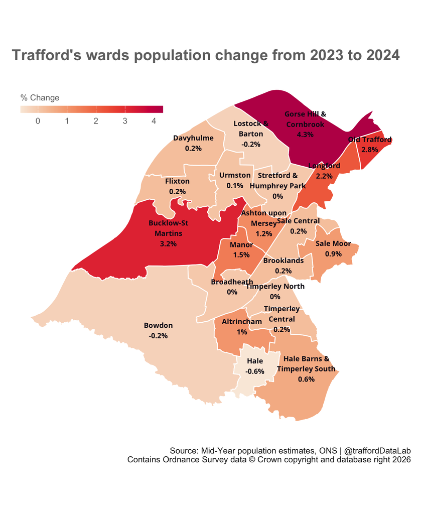

[output not shown]

Source: Mid Year Population estimates | @traffordDataLab

For 6 out of 21 wards, the highest percentage increase in population was in the age band 15 to 24 and the age band 75 and above respectively from 2023 to 2024. Meanwhile, 5 out of 21 of wards experienced the biggest percentage decrease in population in the age band 55 to 64.

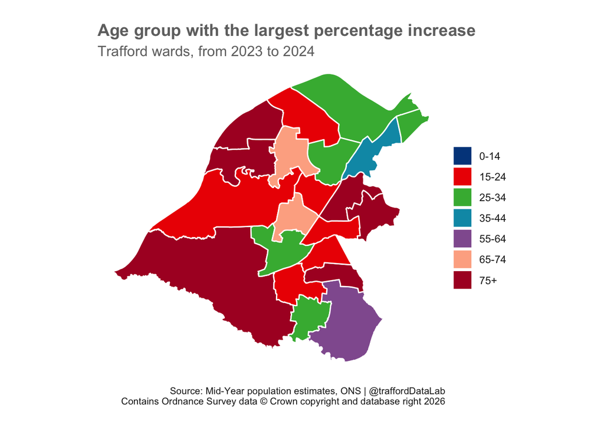

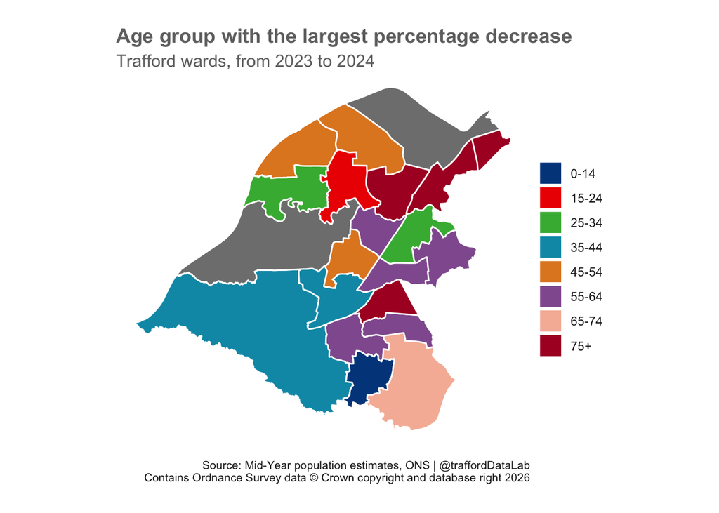

In Gorse Hill & Cornbrook, the ward with the largest increase in population, the five-year age group with the largest rise in population between 2023 and 2024 was age group 85 to 89 with a 16% increase. Gorse Hill & Cornbrook experienced a 1.3% decrease on population on the age band 60 to 64, the largest decrease among five-years age groups for the ward.

Although Hale was the area with the largest decrease in population, Brooklands was the area with the largest decrease by age group with 14% in the 85 to 89 age band.

[interactive chart not shown]

Considering the change of number of residents by age band from 2023 to 2024, the ward with the largest increase was Gorse Hill & Cornbrook with 223 more residents aged 25 to 29 years. The ward with the largest decrease was Stretford & Humphrey Park with -76 less residents aged 50 to 54.

[interactive chart not shown]